# Exemplos - Testes de Hipoteses Parametricos

[figure not shown]

## Códigos - Testes de Hipóteses paramétricos

### Disciplina - Inferência Estatística - Professora - Ana Carolina Dias

```python
import scipy.stats as st
from statistics import mean, stdev
from statsmodels.stats.weightstats import ztest
import statsmodels.api as sm
from scipy.stats import normaltest , norm, shapiro
import numpy as np
import pandas as pd

import warnings
warnings.filterwarnings("ignore", category=DeprecationWarning)

import seaborn as sns
```

# Testes de Hipótese para uma população

# Exemplo - Média Populacional - µ e $σ^2$ conhecido

Uma máquina é programada para encher pacotes de café, com média µ e variância igual a 400g².

Sabemos que a máquina está regulada se a quantidade média de gramas nos pacotes de café é de µ = 500g. Para verificar se a máquina está regulada, colhemos uma amostra de 25 pacotes e verificamos se a produção está sob controle, isto é, se µ = 500g ou não.

Determine se a máquina está regulada, considerando um 𝛼 = 0.01.

## Teste de Normalidade dos dados

```python
amostra_cafe = [501.58, 505.3, 497.62, 511.23, 502.13, 498.45, 496.38, 498.44, 498.45, 488.0, 508.1, 493.79, 505.24,
                492.62, 518.15, 488.77, 495.19, 510.56, 477.39, 508.69, 488.84, 503.39, 499.12, 511.97, 484.84]

significancia= 0.01

stat_test, p_valor = shapiro(amostra_cafe) #Testando a normalidade dos dados - se p-valor > alfa (5%) os dados possuem dist. normal

print('Teste de normalidade dos dados')

if(p_valor <= significancia):
    print('Rejeitamos a Hipótese Nula - Os dados não possuem dist. Normal')
    print('P-valor: ', round(p_valor,2), '<= nível de significancia (alfa):',  round(significancia,2))

else:
    print('Não rejeitamos a Hipótese Nula - Os dados possuem dist. Normal')
    print('P-valor: ', round(p_valor,2), '> nível de significancia (alfa):',  round(significancia,2))
```

```
Teste de normalidade dos dados
Não rejeitamos a Hipótese Nula - Os dados possuem dist. Normal
P-valor:  0.99 > nível de significancia (alfa): 0.01
```

## Teste de hipótese para média $\mu$ (conta na mão)

```python
media_H0 = 500
media_amostral = round(mean(amostra_cafe),2)
nivel_significancia = 0.01
nivel_confianca = 1- nivel_significancia
desvio_populacional = np.sqrt(400) #desvio padrão populacional (raiz da variância)
n = len(amostra_cafe)

print("O tamanho da amostra é de: ", n)
print("A média amostral é: ",media_amostral)
print("O desvio padrão populacional é de: ", desvio_populacional)

print('-----------------------------------------------------------------------------------------')
print('Teste de Hipótese - Z')

z_statistic = (media_amostral - media_H0)/(desvio_populacional/np.sqrt(n)) #  Estatística de Teste
regiao_critica = st.norm.ppf(nivel_significancia/2) # Rejeita se <-regiao_critica ou > regiao_critica

p_value = 2*norm.cdf(z_statistic)

print('Estatística de teste:',  round(z_statistic,3) ,
       '\nRegião crítica =',  round(regiao_critica,3),
       '\nP=valor:',   round(p_value,3))

if(p_value <  significancia):
  print("Rejeitamos a Hipótese Nula")
else:
  print("Não rejeitamos a Hipótese Nula")

print('-----------------------------------------------------------------------------------------')

IC_media = st.norm.interval(nivel_confianca, loc=media_amostral, scale=desvio_populacional/np.sqrt(n))

print("O intervalo de ", nivel_confianca*100 ,
      "% confiança é de: ", [round(num,2) for num in IC_media])
```

```
O tamanho da amostra é de:  25
A média amostral é:  499.37
O desvio padrão populacional é de:  20.0
-----------------------------------------------------------------------------------------
Teste de Hipótese - Z
Estatística de teste: -0.157
Região crítica = -2.576
P=valor: 0.875
Não rejeitamos a Hipótese Nula
-----------------------------------------------------------------------------------------
O intervalo de  99.0 % confiança é de:  [489.07, 509.67]
```

# Exemplo - Média Populacional - µ e $σ^2$ desconhecido

Um fabricante afirma que seus cigarros não contêm mais que 30 mg de nicotina. Uma amostra de 35 cigarros fornece média de 32.1 mg e desvio padrão de 2.2 mg.

No nível de 5%, os dados refutam ou não a afirmação do fabricante?

## Teste de Normalidade dos dados

```python
amostra_cigarro =  [33.81, 31.9, 30.15, 27.55, 32.87, 36.74, 31.75, 30.06, 34.3,
                    33.09, 32.87, 32.25, 32.1, 31.91, 31.13, 30.18, 33.0, 37.04,
                    34.62, 37.12, 33.3, 33.31, 30.91, 28.94, 33.51, 30.68, 31.99,
                    32.12, 31.64, 28.13, 29.21, 31.8, 32.52, 30.24, 30.57]

significancia = 0.05

stat_test, p_valor = shapiro(amostra_cigarro) #Testando a normalidade dos dados - se p-valor > alfa (5%) os dados possuem dist. normal

print('Teste de normalidade dos dados')

if(p_valor <= significancia):
    print('Rejeitamos a Hipótese Nula - Os dados não possuem dist. Normal')
    print('P-valor: ', round(p_valor,2), '<= nível de significancia (alfa):',  round(significancia,2))

else:
    print('Não rejeitamos a Hipótese Nula - Os dados possuem dist. Normal')
    print('P-valor:', round(p_valor,2), '> nível de significancia (alfa):',  round(significancia,2))
```

```
Teste de normalidade dos dados
Não rejeitamos a Hipótese Nula - Os dados possuem dist. Normal
P-valor: 0.32 > nível de significancia (alfa): 0.05
```

## Teste de hipótese para média $\mu$

```python
media_H0 = 30
media_amostral = mean(amostra_cigarro)
desvio_amostral = np.std(amostra_cigarro, ddof=1)  # Desvio padrão amostral (usando ddof=1 para ajuste)
nivel_significancia = 0.05
nivel_confianca = 1 - nivel_significancia

n = len(amostra_cigarro)
graus_de_liberdade = n -1

print("O tamanho da amostra é de: ", n)
print("A média amostral é: ",media_amostral)
print('-----------------------------------------------------------------------------------------')
print('Teste de Hipótese - t\n')

print('Conta na mao:\n')

t = (media_amostral - media_H0) / (desvio_amostral / np.sqrt(n))
regiao_critica = st.t.ppf(nivel_confianca, graus_de_liberdade) # Rejeita se <-regiao_critica ou > regiao_critica

# Calculate P(T > t)
p_value = 1 - st.t.cdf(t , graus_de_liberdade)

print('Estatística de teste:',  round(t,3) ,
       ', Região crítica =',  round(regiao_critica,3),
       '\nP=valor:',   round(p_value,3))

if(p_value <  significancia):
  print("Rejeitamos a Hipótese Nula")
else:
  print("Não rejeitamos a Hipótese Nula")

print('-----------------------------------------------------------------------------------------')

print('Utilizando a funcao python:\n')

media_H0 = 30

t_statistic, p_value = st.ttest_1samp(a=amostra_cigarro, popmean=media_H0, alternative='greater')
print('Estatística de teste:',  round(t_statistic,2) ,'e P=valor:',   round(p_value,2))

if(p_value <  significancia):
  print("Rejeitamos a Hipótese Nula")
else:
  print("Não rejeitamos a Hipótese Nula")

print('-----------------------------------------------------------------------------------------')
print('Intervalo de Confianca:\n')

IC_media = st.t.interval(nivel_confianca, df = n-1,  loc=media_amostral, scale=desvio_amostral/np.sqrt(n))

print("O intervalo de ", nivel_confianca*100 ,
      "% confiança é de: ", [round(num,2) for num in IC_media])
```

```
O tamanho da amostra é de:  35
A média amostral é:  32.09457142857143
-----------------------------------------------------------------------------------------
Teste de Hipótese - t

Conta na mao:

Estatística de teste: 5.534 , Região crítica = 1.691
P=valor: 0.0
Rejeitamos a Hipótese Nula
-----------------------------------------------------------------------------------------
Utilizando a funcao python:

Estatística de teste: 5.53 e P=valor: 0.0
Rejeitamos a Hipótese Nula
-----------------------------------------------------------------------------------------
Intervalo de Confianca:

O intervalo de  95.0 % confiança é de:  [31.33, 32.86]
```

# Exemplo - Proporção Populacional -

Uma empresa desenvolveu uma nova vacina de Covid, e afirma que a proporção de imunizados é maior do que 50%.

Em uma amostra de 726 pessoas que tomaram a vacina, 668 estavam imunizadas.

No nível de 5%, teste a afirmativa de que a proporção de imunizados é maior do que 50%.

```python
sucessos = 668
tentativas = 726
p0 = 0.5

p_chapeu = round(sucessos / tentativas,2)

z_statistic, p_value = sm.stats.proportions_ztest(sucessos, tentativas, value=p0, alternative='larger', prop_var=p0)
regiao_critica = st.norm.ppf(nivel_significancia) # Rejeita se <-regiao_critica ou > regiao_critica

print("Proporção amostral: ", p_chapeu)

# Calcular np0 e n(1 - p0)
np_condition = tentativas * p0
nq_condition = round(tentativas * (1 - p0),2)

# Verificar as condições
print(f"np0 = {np_condition}, n(1 - p0) = {nq_condition}")

# Verificar se ambas as condições são atendidas
if np_condition >= 5 and nq_condition >= 5:
    print("Ambas as condições são atendidas para a aplicação do TCL para proporções.")
else:
    print("As condições necessárias não são atendidas para a aplicação do TCL para proporções.")


print('-----------------------------------------------------------------------------------------')
print('Estatística de teste:',  round(z_statistic,3) ,
       '\nRegião crítica =',  round(regiao_critica,3),
       '\nP=valor:',   round(p_value,3))

if(p_value <  significancia):
  print("Rejeitamos a Hipótese Nula")
else:
  print("Não rejeitamos a Hipótese Nula")
```

```
Proporção amostral:  0.92
np0 = 363.0, n(1 - p0) = 363.0
Ambas as condições são atendidas para a aplicação do TCL para proporções.
-----------------------------------------------------------------------------------------
Estatística de teste: 22.639
Região crítica = -1.645
P=valor: 0.0
Rejeitamos a Hipótese Nula
```

# Exemplo - Variância Populacional - $σ^2$

```python
amostra_medicamento  = [0.15,0.18,0.18,0.20,0.21,0.22,0.25,0.27,0.17,0.18,0.19,0.20,0.21,0.22,0.26,0.27]

nivel_significancia= 0.05
stat_test, p_valor = shapiro(amostra_medicamento) #Testando a normalidade dos dados - se p-valor > alfa (5%) os dados possuem dist. normal

print('Teste de normalidade dos dados')

if(p_valor <= significancia):
    print('Rejeitamos a Hipótese Nula - Os dados não possuem dist. Normal')
    print('P-valor: ', round(p_valor,2), '<= nível de significancia (alfa):',  round(significancia,2))

else:
    print('Não rejeitamos a Hipótese Nula - Os dados possuem dist. Normal')
    print('P-valor: ', round(p_valor,2), '> nível de significancia (alfa):',  round(significancia,2))
```

```
Teste de normalidade dos dados
Não rejeitamos a Hipótese Nula - Os dados possuem dist. Normal
P-valor:  0.32 > nível de significancia (alfa): 0.05
```

```python
from scipy.stats import chi2

variancia_H0 = 0.0009
variancia_amostral = np.var(amostra_medicamento, ddof = 1).round(4) # variancia amostral
nivel_confianca = 1 - nivel_significancia

n = len(amostra_medicamento)
graus_de_liberdade = n -1

print("O tamanho da amostra é de: ", n)
print("A variância amostral é: ",variancia_amostral)
print("Graus de liberdade: ", graus_de_liberdade)

print('-----------------------------------------------------------------------------------------')
print('Teste de Hipótese - Qui quadrado\n')

print('Conta na mao:\n')

qui_quadrado = ((n-1)*variancia_amostral) / (variancia_H0)
regiao_critica = chi2.ppf(1 - significancia, graus_de_liberdade) # Rejeita se <-regiao_critica ou > regiao_critica

# Calculate P(X > x)
p_value = 1 - chi2.cdf(qui_quadrado, graus_de_liberdade)

# Exibir os resultados de forma mais legível
print('Estatística de Teste qui-quadrado:',  round(qui_quadrado,3) ,
       '\nRegião crítica =',  round(regiao_critica,3),
       '\nP=valor:',   round(p_value,3))

if(p_value <  significancia):
  print("Rejeitamos a Hipótese Nula")
else:
  print("Não rejeitamos a Hipótese Nula")
```

```
O tamanho da amostra é de:  16
A variância amostral é:  0.0013
Graus de liberdade:  15
-----------------------------------------------------------------------------------------
Teste de Hipótese - Qui quadrado

Conta na mao:

Estatística de Teste qui-quadrado: 21.667
Região crítica = 24.996
P=valor: 0.117
Não rejeitamos a Hipótese Nula
```

Testes de Hipótese para DUAS populações

> Médias

# Exemplo - Médias de duas Populações independentes - $σ^2$ conhecidos

## Exemplo - tempos de entrega

Uma transportadora de mercadorias tem duas possibilidades de trajeto para realizar entregas. O gerente de logística desconfia não haver diferença significativa entre o tempo de cada trajeto.

Foram selecionadas aleatoriamente 45 entregas realizadas no primeiro trajeto, resultando em uma média amostral de 57 minutos. No segundo trajeto, foram selecionadas aleatoriamente 30 entregas, e o tempo médio foi de 54 minutos.

O desvio-padrão populacional do primeiro trajeto é de σ1 = 8 minutos, e o do segundo trajeto é de σ2 = 6 minutos.

Teste a hipótese de que não existe diferença significativa entre o tempo médio dos dois trajetos, ao nível de 1% de significância.

Amostra_trajeto1 = [50.86, 63.98, 58.47, 74.52, 50.53, 50.28, 52.2, 40.01, 52.79, 50.93, 58.2, 59.73, 72.01, 64.6, 52.38, 49.81, 60.94, 46.44, 71.65, 66.44, 53.25, 43.29, 67.83, 56.08, 66.9, 44.24, 52.2, 57.04, 57.38, 53.4, 61.98, 48.46, 55.86, 57.96, 61.12, 62.69, 48.0, 44.73, 67.22, 59.66, 51.01, 69.41, 57.93, 66.43, 57.54] Amostra_trajeto2 =[66.36, 64.53, 52.51, 59.83, 57.87, 62.21, 48.21, 58.12, 60.35, 43.45, 46.9, 41.76, 52.38, 58.31, 63.01, 54.44, 63.77, 45.72, 43.78, 53.67, 56.3, 53.8, 41.6, 53.47, 46.17, 58.02, 56.2, 48.36, 50.92, 47.64]

```python
Amostra_trajeto1 = [50.86, 63.98, 58.47, 74.52, 50.53, 50.28, 52.2, 40.01, 52.79, 50.93, 58.2, 59.73, 72.01,
                    64.6, 52.38, 49.81, 60.94, 46.44, 71.65, 66.44, 53.25, 43.29, 67.83, 56.08, 66.9, 44.24,
                    52.2, 57.04, 57.38, 53.4, 61.98, 48.46, 55.86, 57.96, 61.12, 62.69, 48.0, 44.73, 67.22,
                    59.66, 51.01, 69.41, 57.93, 66.43, 57.54]

Amostra_trajeto2 = [66.36, 64.53, 52.51, 59.83, 57.87, 62.21, 48.21, 58.12, 60.35, 43.45, 46.9, 41.76,
                   52.38, 58.31, 63.01, 54.44, 63.77, 45.72, 43.78, 53.67, 56.3, 53.8, 41.6, 53.47,
                   46.17, 58.02, 56.2, 48.36, 50.92, 47.64]


n1, n2 = len(Amostra_trajeto1), len(Amostra_trajeto2)

 # Médias das amostras
mean1, mean2 = np.mean(Amostra_trajeto1).round(0), np.mean(Amostra_trajeto2).round(0)

print("O tamanho da amostra 1 é de:", n1)
print("O tamanho da amostra 2 é de:", n2)
print("A variância amostral da amostra 1 é:", mean1)
print("A variância amostral da amostra 2 é:", mean2)
```

```
O tamanho da amostra 1 é de: 45
O tamanho da amostra 2 é de: 30
A variância amostral da amostra 1 é: 57.0
A variância amostral da amostra 2 é: 54.0
```

```python
from scipy.stats import norm
import numpy as np

def two_sample_ztest(sample1, sample2, sigma1_squared, sigma2_squared, alpha=0.05, alternative="two-sided"):
    """
    Realiza um teste de hipóteses para as médias de duas populações independentes com variâncias conhecidas.

    Argumentos:
    - sample1, sample2: As amostras das duas populações.
    - sigma1_squared, sigma2_squared: As variâncias conhecidas das populações.
    - alpha: Nível de significância (padrão: 0.05).
    - alternative: Especifica a hipótese alternativa. Pode ser "two-sided" (padrão), "less" (menor) ou "greater" (maior).

    Retorna:
    - estatistica_teste: A estatística de teste.
    - p_valor: O valor p do teste de hipóteses.
    - rejeitar_nula: Um booleano indicando se a hipótese nula é rejeitada.
    - intervalo_confianca: O intervalo de confiança para a diferença das médias.
    - valor_critico: O valor crítico para o teste de hipótese com base na hipótese alternativa.
    """
    # Tamanho das amostras
    n1, n2 = len(sample1), len(sample2)

    # Médias das amostras
    mean1, mean2 = np.mean(sample1).round(0), np.mean(sample2).round(0)

    # Diferença das médias
    mean_difference = mean1 - mean2

    # Desvio padrão combinado
    combined_std = np.sqrt((sigma1_squared / n1) + (sigma2_squared / n2)).round(6)

    # Estatística de teste
    z_statistic = mean_difference / combined_std

    # Teste de hipóteses
    if alternative == "two-sided":
        p_value = 2 * (1 - norm.cdf(np.abs(z_statistic)))
        valor_critico = norm.ppf(1 - alpha / 2)
    elif alternative == "less":
        p_value = norm.cdf(z_statistic)
        valor_critico = norm.ppf(alpha)
    elif alternative == "greater":
        p_value = 1 - norm.cdf(z_statistic)
        valor_critico = norm.ppf(1 - alpha)
    else:
        raise ValueError("O argumento 'alternative' deve ser 'two-sided', 'less' ou 'greater'.")

    # Prints solicitados
    print("O tamanho da amostra 1 é de:", n1)
    print("O tamanho da amostra 2 é de:", n2)
    print("A variância da população  1 é:", sigma1_squared)
    print("A variância da população 2 é:", sigma2_squared)
    print("Valor Crítico:", valor_critico.round(3))

    # Testar a hipótese nula
    print("Estatística de teste:", z_statistic.round(3))
    print("P-valor:", p_value.round(3))
    if(p_value <  alpha):
      print("Rejeitamos a Hipótese Nula")
    else:
      print("Não rejeitamos a Hipótese Nula")

    return z_statistic, p_value, valor_critico
```

```python
sigma1 = 8**2
sigma2 = 6**2

resultado_teste = two_sample_ztest(Amostra_trajeto1, Amostra_trajeto2, sigma1, sigma2, alpha=0.01, alternative="two-sided")
```

```
O tamanho da amostra 1 é de: 45
O tamanho da amostra 2 é de: 30
A variância da população  1 é: 64
A variância da população 2 é: 36
Valor Crítico: 2.576
Estatística de teste: 1.853
P-valor: 0.064
Não rejeitamos a Hipótese Nula
```

# Exemplo - Médias de duas Populações independentes - $σ^2$ desconhecidos - Vâriancias iguais $σ_1^2 = σ_2^2$

Em uma avaliação de estatística, foi selecionada uma amostra de 12 alunos da turma A, resultando em uma média de 7.9 com desvio-padrão 0.6.

Na turma B, foram selecionados 15 alunos, os quais tiraram nota média 6.7 com desvio-padrão 0.8.

Foram feitos testes de normalidade e igualdade das variâncias e determinou se que as notas possuem distribuição normal e $σ_1^2 = σ_2^2$,

Teste a hipótese de que a turma A tem média maior do que a turma B, com um nível de significância de 1%.

TurmaA = [8.04, 7.76, 7.8, 8.46, 8.82, 7.88, 7.4, 7.05, 8.63, 8.25, 8.01, 6.94]

TurmaB = [7.94, 6.07, 6.44, 7.35, 5.72, 6.88, 7.75, 5.41, 6.85, 6.91, 7.33, 5.71, 5.64, 7.12, 6.94]

```python
TurmaA = [8.04, 7.76, 7.8, 8.46, 8.82, 7.88, 7.4, 7.05, 8.63, 8.25, 8.01, 6.94]
TurmaB = [7.94, 6.07, 6.44, 7.35, 5.72, 6.88, 7.75, 5.41, 6.85, 6.91, 7.33, 5.71, 5.64, 7.12, 6.94]

print("Turma A - Amostra:")
print("n:", len(TurmaA))
print("Média:", np.mean(TurmaA).round(1))
print("Desvio padrão:",np.std(TurmaA, ddof = 1).round(1))

print("\n")

print("Turma B - Amostra:")
print("n:", len(TurmaB))
print("Média:", np.mean(TurmaB).round(1))
print("Desvio padrão:", np.std(TurmaB, ddof = 1).round(2))

nivel_significancia = 0.01
```

```
Turma A - Amostra:
n: 12
Média: 7.9
Desvio padrão: 0.6


Turma B - Amostra:
n: 15
Média: 6.7
Desvio padrão: 0.8
```

# Teste de normalidade dos dados

A função *shapiro* testa a hipótese nula $H_0$ de que a amostra é proveniente de uma distribuição normal.

$$\begin{cases} H_0 = \text{Dados vem de uma normal}\\H_1 = \text{Dados não vem de uma normal}\end{cases} $$

```python
def teste_normalidade_e_conclusao(dados, Pop, nivel_significancia=0.05):
    # Realizar o teste de normalidade de Shapiro-Wilk
    stat_test, p_valor = shapiro(dados)

    # Exibir os resultados
    print(f'\n{Pop} - Teste de Shapiro-Wilk: Estatística de Teste = {round(stat_test, 2)}, P-valor = {round(p_valor, 4)}')

    # Conclusão
    if p_valor < nivel_significancia:
        print(f"Rejeita-se a hipótese nula. Os dados da {Pop} não seguem uma distribuição normal.")
    else:
        print(f"Não há evidências para rejeitar a hipótese nula. Os dados da {Pop} podem ser considerados aproximadamente normais.")
```

```python
# Aplicar a função para Turma A
teste_normalidade_e_conclusao(TurmaA, "Turma A",nivel_significancia = 0.01)

# Aplicar a função para Turma B
teste_normalidade_e_conclusao(TurmaB, "Turma B",nivel_significancia = 0.01)
```

```
Turma A - Teste de Shapiro-Wilk: Estatística de Teste = 0.97, P-valor = 0.862
Não há evidências para rejeitar a hipótese nula. Os dados da Turma A podem ser considerados aproximadamente normais.

Turma B - Teste de Shapiro-Wilk: Estatística de Teste = 0.94, P-valor = 0.3565
Não há evidências para rejeitar a hipótese nula. Os dados da Turma B podem ser considerados aproximadamente normais.
```

# Teste de homogeinedade das variancias (variancias iguais)

$$\begin{cases} H_0: \text{as amostras possuem variâncias iguais}\\H_1: \text{as amostras possuem variâncias diferentes}\end{cases} $$

```python
stat_test, p_valor = st.bartlett(TurmaA, TurmaB)

# Exibir os resultados de forma mais legível
print(f"Teste de Bartlett - Estatística de Teste: {round(stat_test, 2)}, P-valor: {round(p_valor, 4)}")

if p_valor < nivel_significancia:
    print("Rejeita-se a hipótese nula. As variâncias não são iguais.")
else:
    print("Não há evidências para rejeitar a hipótese nula. As variâncias são iguais.")
```

```
Teste de Bartlett - Estatística de Teste: 1.12, P-valor: 0.2906
Não há evidências para rejeitar a hipótese nula. As variâncias são iguais.
```

# Teste de hipotese independente - Vâriancias iguais $σ_1^2 = σ_2^2$

A função *ttest_ind* testa a hipótese nula $H_0$ de que os grupos 1 (Turma A) e 2 (Turma B) tem o valor médio das notas de estatística iguais.

$$\begin{cases} H_0 = \text{Nota média Turma A é igual a nota média da Turma B = $\mu_A = \mu_B$}\\H_1 = \text{Nota média Turma A é maior que a nota média da Turma B = $\mu_A > \mu_B$} \end{cases}$$

```python
# Realizar o teste t de Student para médias independentes
stat_test, p_valor = st.ttest_ind(a=TurmaA, b=TurmaB, equal_var=True, alternative='greater')

# Nível de significância
nivel_significancia = 0.01

# Exibir os resultados de forma mais legível
print(f"Teste t de Student - Estatística de Teste: {round(stat_test, 2)}, P-valor: {round(p_valor, 4)}")

if p_valor < nivel_significancia:
    print("Rejeita-se a hipótese nula. A média da Turma A é significativamente maior que a média da Turma B.")
else:
    print("Não há evidências para rejeitar a hipótese nula. Não podemos afirmar que a média da Turma A é maior que a média da Turma B.")
```

```
Teste t de Student - Estatística de Teste: 4.52, P-valor: 0.0001
Rejeita-se a hipótese nula. A média da Turma A é significativamente maior que a média da Turma B.
```

# Exemplo - Médias de duas Populações independentes - $σ^2$ desconhecidos - Vâriancias diferentes $σ_1^2 \neq σ_2^2$

## Exemplo: tempo de uma tarefa doméstica

Uma pesquisa avaliou a eficácia de dois tipos de treinamento, com a finalidade de reduzir o tempo médio de determinada tarefa doméstica.

Foram selecionadas duas amostras aleatórias e determinou-se através de testes de hipóteses que as populações possuem distribuição normal e $σ_1^2 \neq σ_2^2$.

Os dados da pesquisa estão abaixo. Teste a hipótese de que o tempo médio para a realização da tarefa é igual para os dois treinamentos, ao nível de 5% de significância.

Treinamento1 = [19.7, 23.36, 22.84, 26.06, 19.15, 25.66, 30.6, 19.89, 24.8, 22.11, 25.55, 24.26, 22.17, 25.74, 29.9]

Treinamento2 = [16.06, 25.63, 36.46, 14.7, 23.74, 27.1, 24.52, 23.33, 17.4, 25.06]

```python
Treinamento1 = [19.7, 23.36, 22.84, 26.06, 19.15, 25.66, 30.6, 19.89, 24.8, 22.11, 25.55, 24.26, 22.17, 25.74, 29.9]
Treinamento2 = [16.06, 25.63, 36.46, 14.7, 23.74, 27.1, 24.52, 23.33, 17.4, 25.06]

print("Treinamento 1 - Amostra:")
print("n:", len(Treinamento1))
print("Média:", np.mean(Treinamento1).round(1))
print("Desvio padrão:",np.std(Treinamento1, ddof = 1).round(1))

print("\n")

print("Treinamento 2 - Amostra:")
print("n:", len(Treinamento2))
print("Média:", np.mean(Treinamento2).round(1))
print("Desvio padrão:",np.std(Treinamento2, ddof = 1).round(1))

nivel_significancia = 0.05
```

```
Treinamento 1 - Amostra:
n: 15
Média: 24.1
Desvio padrão: 3.4


Treinamento 2 - Amostra:
n: 10
Média: 23.4
Desvio padrão: 6.3
```

```python
teste_normalidade_e_conclusao(Treinamento1, "Treinamento 1",nivel_significancia = 0.05)
teste_normalidade_e_conclusao(Treinamento2, "Treinamento 2",nivel_significancia = 0.05)
```

```
Treinamento 1 - Teste de Shapiro-Wilk: Estatística de Teste = 0.95, P-valor = 0.4746
Não há evidências para rejeitar a hipótese nula. Os dados da Treinamento 1 podem ser considerados aproximadamente normais.

Treinamento 2 - Teste de Shapiro-Wilk: Estatística de Teste = 0.92, P-valor = 0.3182
Não há evidências para rejeitar a hipótese nula. Os dados da Treinamento 2 podem ser considerados aproximadamente normais.
```

```python
# Realizar o teste de Bartlett para igualdade de variâncias
stat_test, p_valor = st.bartlett(Treinamento1, Treinamento2)

# Exibir os resultados de forma mais legível
print(f"Teste de Bartlett - Estatística de Teste: {round(stat_test, 2)}, P-valor: {round(p_valor, 4)}")

if p_valor < nivel_significancia:
    print("Rejeita-se a hipótese nula. As variâncias não são iguais.")
else:
    print("Não há evidências para rejeitar a hipótese nula. As variâncias são iguais.")
```

```
Teste de Bartlett - Estatística de Teste: 4.25, P-valor: 0.0393
Rejeita-se a hipótese nula. As variâncias não são iguais.
```

Escolha entre Bartlett e Levene:

A escolha entre Bartlett e Levene depende das características dos seus dados. Se você tem razão para acreditar que suas amostras vêm de distribuições normais, o teste de Bartlett pode ser a escolha. Se você está menos certo sobre a normalidade dos dados, ou se tem razões para acreditar que as amostras não seguem distribuições normais, o teste de Levene pode ser uma escolha mais robusta. Em geral, é uma boa prática realizar ambos os testes e considerar os resultados em conjunto.

# Teste de hipotese independente - Vâriancias diferentes $σ_1^2 \neq σ_2^2$

A função *ttest_ind* testa a hipótese nula $H_0$ de que os grupos 1 e 2 tem o valor médio das notas de estatística iguais.

$$\begin{cases} H_0 = \text{ $\mu_1 = \mu_2$}\\H_1 = \text{$\mu_1 \neq \mu_2$} \end{cases}$$

```python
# Realizar o teste t de Student para médias independentes
stat_test, p_valor = st.ttest_ind(a=Treinamento1, b=Treinamento2, equal_var=False, alternative='two-sided')


# Exibir os resultados de forma mais legível
print(f"Teste t de Student - Estatística de Teste: {round(stat_test, 2)}, P-valor: {round(p_valor, 4)}")

print(f"Região-crítica: {st.t.ppf(1 - nivel_significancia/2, 13).round(2)}")

if p_valor < nivel_significancia:
    print("Rejeita-se a hipótese nula.")
else:
    print("Não há evidências para rejeitar a hipótese nula.")
```

```
Teste t de Student - Estatística de Teste: 0.33, P-valor: 0.7467
Região-crítica: 2.16
Não há evidências para rejeitar a hipótese nula.
```

# Teste de hipotese Dependente - Média de duas populações dependentes

## Exemplo: manutenção preventiva

Em uma fábrica, sete máquinas foram selecionadas aleatoriamente a fim de determinar o efeito da manutenção preventiva na produção.

Inicialmente, as máquinas trabalharam por um período na forma habitual, e depois trabalham o mesmo período recebendo manutenções preventivas.

O total de trabalho produzido, antes e depois da adoção das manutenções, está na tabela ao lado.

Ao nível de 5%, podemos concluir que o trabalho médio produzido é maior depois da adoção das manutenções preventivas?

dados_antes = [12.10, 12.30, 11.10, 12.80, 14.10, 8.40, 13.30]

dados_depois = [12.50, 16.00, 12.90, 14.00, 12.90, 12.50, 13.50]

```python
dados_antes = np.array([12.10, 12.30, 11.10, 12.80, 14.10, 8.40, 13.30])
dados_depois = np.array([12.50, 16.00, 12.90, 14.00, 12.90, 12.50, 13.50])

diferenca = dados_antes - dados_depois
diferenca
```

```
array([-0.4, -3.7, -1.8, -1.2,  1.2, -4.1, -0.2])
```

## Teste de normalidade dos dados

```python
nivel_significancia = 0.05

teste_normalidade_e_conclusao(diferenca, "Diferença", nivel_significancia =nivel_significancia)
```

```
Diferença - Teste de Shapiro-Wilk: Estatística de Teste = 0.95, P-valor = 0.7047
Não há evidências para rejeitar a hipótese nula. Os dados da Diferença podem ser considerados aproximadamente normais.
```

# Teste de hipotese pareado (related)

A função *ttest_reg* testa a hipótese nula $H_0$ de que a diferença das médias é igual a zero.

$$\begin{cases} H_0 = \text{Trabalho produzido antes da manutenção e após a manutenção = 0 } = \mu_d =0\\H_1 = \text{Trabalho produzido antes da manutenção < após a manutenção} < 0 = \mu_d < 0 \end{cases} $$

```python
stat_test, p_valor = st.ttest_rel(dados_antes,dados_depois, alternative='less')

# Exibir os resultados de forma mais legível
print(f"Teste t de Student - Estatística de Teste: {round(stat_test, 3)}, P-valor: {round(p_valor, 4)}")
print(f"Região-crítica: {st.t.ppf(1 - nivel_significancia, 6).round(3)}")

if p_valor < nivel_significancia:
    print("Rejeita-se a hipótese nula.")
else:
    print("Não há evidências para rejeitar a hipótese nula.")
```

```
Teste t de Student - Estatística de Teste: -2.015, P-valor: 0.0452
Região-crítica: 1.943
Rejeita-se a hipótese nula.
```

> Proporções

# Exemplo - Proporções de duas Populações Independentes

Em um estudo com 2870 motoristas, 1210 afirmaram ter o hábito de mexer no celular com o carro em movimento. Depois de sancionada uma multa, foi realizado outro estudo com 2200 motoristas, dos quais 725 afirmaram ter ainda o hábito.

Usando um nível de significância de 10%, é possível verificar a alegação de que a proporção de motoristas com hábito de mexer no celular no trânsito diminuiu significativamente após a criação da multa?

p = proporção de motorista que usam o celular com o carro em movimento.

$$\begin{cases} H_0 = p_1 - p_2 = 0\\H_1 = p_1 - p_2 > 0 \end{cases} $$

```python
import statsmodels.api as sm

# Dados de exemplo
successes_A = 1210  # Número de motorista que afirmaram ter o hábito de mexer no celular com o carro em movimento
nobs_A = 2870      # Número total de observações na amostra Antes da multa

successes_D = 725  #  Número de motorista que afirmaram ter o hábito de mexer no celular com o carro em movimento
nobs_D = 2200      # Número total de observações na amostra depois da multa

nivel_significancia = 0.10

p_barra = round((successes_A + successes_D) / (nobs_A+nobs_D),3)
print(p_barra)

success_cnts = [successes_A, successes_D]
total_cnts = [nobs_A, nobs_D]

# Realizar o teste de proporções de duas amostras
z_stat, p_value = sm.stats.proportions_ztest(success_cnts, total_cnts, prop_var = p_barra)

# Exibir os resultados de forma mais legível
print(f"Teste t de Student - Estatística de Teste: {round(z_stat, 3)}, P-valor: {round(p_value, 4)}")
print(f"Região-crítica: {norm.ppf(1 - nivel_significancia).round(3)}")

# Tomar uma decisão com base no p-valor

if p_value < nivel_significancia:
    print("Rejeita-se a hipótese nula. Há evidências estatísticas de diferença nas proporções.")
else:
    print("Não há evidências para rejeitar a hipótese nula. Não há diferença estatisticamente significativa nas proporções.")
```

```
0.382
Teste t de Student - Estatística de Teste: 6.686, P-valor: 0.0
Região-crítica: 1.282
Rejeita-se a hipótese nula. Há evidências estatísticas de diferença nas proporções.
```

> Variâncias de duas populações

```python
Antes_1964 = [6.31, 6.3, 6.35, 6.16, 6.06, 6.33, 6.19, 6.08, 6.27, 6.33,
              6.25, 6.22, 6.25, 6.23, 6.14, 6.2, 6.31, 6.29, 6.27, 6.17,
              6.24, 6.07, 6.28, 6.38, 6.13, 6.21, 6.29, 6.37, 6.22, 6.2,
              6.09, 6.27, 6.44, 6.28, 6.26, 6.29, 6.26, 6.19, 6.33, 6.28]


Depois_1964 = [6.31, 6.36, 6.21, 6.29, 6.32, 6.26, 6.12, 6.28, 6.31, 6.2, 6.24, 6.19, 6.1, 6.32,
               6.26, 6.36, 6.31, 6.24, 6.25, 6.3, 6.32, 6.28, 6.33, 6.24, 6.2, 6.26, 6.27, 6.19,
               6.18, 6.29, 6.23, 6.25, 6.24, 6.35, 6.34, 6.18, 6.23, 6.32, 6.3, 6.3]


print("Antes_1964 - Amostra:")
print("n:", len(Antes_1964))
print("Média:", np.mean(Antes_1964).round(2))
print("Desvio padrão:",np.std(Antes_1964, ddof = 1).round(3))

print("\n")

print("Depois_1964 - Amostra:")
print("n:", len(Depois_1964))
print("Média:", np.mean(Depois_1964).round(2))
print("Desvio padrão:",np.std(Depois_1964, ddof = 1).round(5))
```

```
Antes_1964 - Amostra:
n: 40
Média: 6.24
Desvio padrão: 0.087


Depois_1964 - Amostra:
n: 40
Média: 6.26
Desvio padrão: 0.06191
```

```python
nivel_significancia = 0.05
teste_normalidade_e_conclusao(Antes_1964, "Antes 1964 ",nivel_significancia)
teste_normalidade_e_conclusao(Depois_1964, "Depois 1964",nivel_significancia)
```

```
Antes 1964  - Teste de Shapiro-Wilk: Estatística de Teste = 0.97, P-valor = 0.4953
Não há evidências para rejeitar a hipótese nula. Os dados da Antes 1964  podem ser considerados aproximadamente normais.

Depois 1964 - Teste de Shapiro-Wilk: Estatística de Teste = 0.96, P-valor = 0.1623
Não há evidências para rejeitar a hipótese nula. Os dados da Depois 1964 podem ser considerados aproximadamente normais.
```

```python
from scipy.stats import f

variance_group1 = np.var(Antes_1964, ddof=1)
variance_group2 = np.var(Depois_1964, ddof=1)

F_statistic = variance_group1 / variance_group2
df_num = len(Antes_1964) - 1
df_den = len(Depois_1964) - 1
p_value = 2 * (1 - f.cdf(F_statistic, df_num, df_den))
critical_value = f.ppf(1 - nivel_significancia / 2, df_num, df_den)

# Display results
print(f"F-statistic: {round(F_statistic, 3)}")
print(f"P-value: {round(p_value, 4)}")
print(f"Critical Region: F > {round(critical_value, 2)}")

if p_valor < nivel_significancia:
    print("Rejeita-se a hipótese nula. As variâncias não são iguais.")
else:
    print("Não há evidências para rejeitar a hipótese nula. As variâncias são iguais.")
```

```
F-statistic: 1.968
P-value: 0.0374
Critical Region: F > 1.89
Rejeita-se a hipótese nula. As variâncias não são iguais.
```

```python
import numpy as np

# Definir semente para reproduzibilidade

# Dados da turma A
media_A = 6.7
desvio_padrao_A = 0.8
tamanho_amostra_A = 15
amostra_A = np.random.normal(loc=media_A, scale=desvio_padrao_A, size=tamanho_amostra_A).round(2)

print(amostra_A)
print(np.mean(amostra_A))
print(np.std(amostra_A, ddof = 1))
```

```
[5.38 5.6  6.73 6.05 7.05 5.33 7.39 7.95 6.2  8.68 5.7  7.45 5.79 5.62
 7.03]
6.530000000000002
1.028750976392524
```

# Testes de Hipótese para 3 OU MAIS populações

> ANOVA UMA VIA

$$\begin{cases} H_0: \mu_1 = \mu_2 = \mu_3 ...= \mu_k \text{ (todas as médias são iguais)}\\H_1: \text{Pelo menos uma é diferente das demais} \end{cases} $$

```python
import pandas as pd

dados_tratamentos = pd.read_csv('Hipertensao.csv', sep= ';', decimal= ',')
dados_tratamentos.head(5)
```

|  | Sujeito | Grupo | Pressao | BC | Triglicerides | Glicemia |
| --- | --- | --- | --- | --- | --- | --- |
| 0 | 21 | Placebo | 175.33 | 356.33 | 65.84 | 93 |
| 1 | 30 | Placebo | 158.00 | 378.00 | 148.15 | 109 |
| 2 | 27 | Placebo | 163.67 | 397.33 | 115.23 | 112 |
| 3 | 20 | Placebo | 184.67 | 435.33 | 76.54 | 113 |
| 4 | 31 | Placebo | 171.67 | 365.33 | 73.25 | 115 |

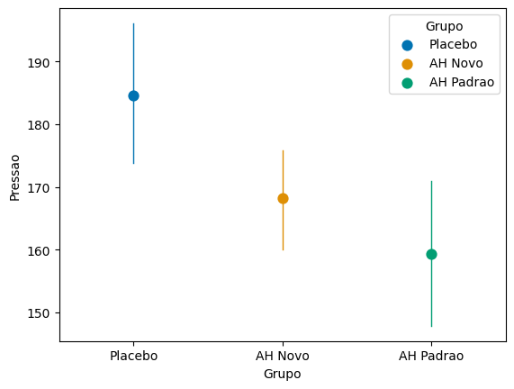

```python
sns.pointplot(data=dados_tratamentos, x='Grupo', y='Pressao', hue='Grupo',  errwidth=1, palette='colorblind')
```

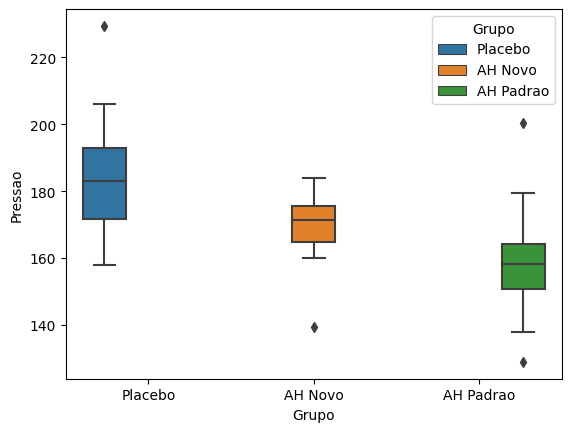

```python
sns.boxplot(x='Grupo', y='Pressao', data=dados_tratamentos, hue='Grupo')
```

# Teste de normalidade dos dados

A função *shapiro* testa a hipótese nula $H_0$ de que a amostra é proveniente de uma distribuição normal.

$$\begin{cases} H_0 = \text{Dados vem de uma normal}\\H_1 = \text{Dados não vem de uma normal}\end{cases} $$

```python
Placebo = dados_tratamentos.query('Grupo == "Placebo"').Pressao
TratNovo = dados_tratamentos.query('Grupo == "AH Novo"').Pressao
Padrao = dados_tratamentos.query('Grupo == "AH Padrao"').Pressao
```

```python
nivel_significancia = 0.05

teste_normalidade_e_conclusao(Placebo, "Placebo", nivel_significancia)
teste_normalidade_e_conclusao(TratNovo, "Trat Novo", nivel_significancia)
teste_normalidade_e_conclusao(Padrao, "Trat Padrão", nivel_significancia)
```

```
Placebo - Teste de Shapiro-Wilk: Estatística de Teste = 0.94, P-valor = 0.5331
Não há evidências para rejeitar a hipótese nula. Os dados da Placebo podem ser considerados aproximadamente normais.

Trat Novo - Teste de Shapiro-Wilk: Estatística de Teste = 0.91, P-valor = 0.2842
Não há evidências para rejeitar a hipótese nula. Os dados da Trat Novo podem ser considerados aproximadamente normais.

Trat Padrão - Teste de Shapiro-Wilk: Estatística de Teste = 0.95, P-valor = 0.7226
Não há evidências para rejeitar a hipótese nula. Os dados da Trat Padrão podem ser considerados aproximadamente normais.
```

# Teste de homogeinedade das variancias (variancias iguais)

$$\begin{cases} H_0: \text{as amostras possuem variâncias iguais}\\H_1: \text{pelo menos uma é diferente}\end{cases} $$

```python
# Testando a homogeinedade das variancias pelo teste de Levene
stat_test, p_valor = st.levene(Placebo, TratNovo, Padrao, center='mean')

# Exibir os resultados de forma mais legível
print(f"Teste de Levene - Estatística de Teste: {round(stat_test, 2)}, P-valor: {round(p_valor, 4)}")

if p_valor < nivel_significancia:
    print("Rejeita-se a hipótese nula. As variâncias não são iguais.")
else:
    print("Não há evidências para rejeitar a hipótese nula. As variâncias são iguais.")
```

```
Teste de Levene - Estatística de Teste: 0.47, P-valor: 0.6323
Não há evidências para rejeitar a hipótese nula. As variâncias são iguais.
```

# Comparando a média dos 3 grupos - ANOVA

$$\begin{cases} H_0: \mu_1 = \mu_2 = \mu_3 \text{ (todas as médias são iguais)}\\H_1: \text{Pelo menos uma é diferente das demais} \end{cases} $$

$$\begin{cases} H_0 = \text{A diferença da média dos 3 grupos} = 0 \\H_1 = \text{A diferença da média dos 3 grupos} \neq 0 \end{cases} $$

```python
stat_test, p_valor = st.f_oneway(Placebo, TratNovo, Padrao )

# Exibir os resultados de forma mais legível
print(f"Teste Anova de uma via - Estatística de Teste: {round(stat_test, 2)}, P-valor: {round(p_valor, 4)}")
if p_valor < nivel_significancia:
    print("Rejeita-se a hipótese nula. Pelo menos uma média é diferente.")
else:
    print("Não há evidências para rejeitar a hipótese nula. As médias são iguais.")
```

```
Teste Anova de uma via - Estatística de Teste: 5.52, P-valor: 0.0095
Rejeita-se a hipótese nula. Pelo menos uma média é diferente.
```

```python
import statsmodels.api as sm
from statsmodels.formula.api import ols

# Ordinary Least Squares (OLS) model
model = ols('Pressao ~ Grupo', data=dados_tratamentos).fit()
anova_table = sm.stats.anova_lm(model, typ=1)
anova_table
```

|  | df | sum_sq | mean_sq | F | PR(>F) |
| --- | --- | --- | --- | --- | --- |
| Grupo | 2.0 | 3631.035134 | 1815.517567 | 5.520544 | 0.009526 |
| Residual | 28.0 | 9208.239137 | 328.865683 | NaN | NaN |

# Teste Post hoc - detectando quais grupos são diferentes

- Tukey - hsd - Moderado

```python
from statsmodels.stats.multicomp import pairwise_tukeyhsd

m_comp = pairwise_tukeyhsd(endog=dados_tratamentos['Pressao'],
                           groups=dados_tratamentos['Grupo'], alpha=0.05)
print(m_comp)

#Verificamos que existe diferença entre os tratamentos,
#ou seja há efeito do tratamento sobre a pressão arterial.
#O post-hoc do teste de Tukey hsd mostrou que
#existe diferença entre o placebo e entre o grupo de anti hipertensivo padrão.
```

```
    Multiple Comparison of Means - Tukey HSD, FWER=0.05
===========================================================
  group1    group2  meandiff p-adj   lower    upper  reject
-----------------------------------------------------------
  AH Novo AH Padrao  -8.8232 0.5469 -29.4402 11.7938  False
  AH Novo   Placebo  16.4169 0.1183  -3.3695 36.2034  False
AH Padrao   Placebo  25.2402 0.0082   6.0273  44.453   True
-----------------------------------------------------------
```

- Bonferroni - Mais conservador

```python
from itertools import combinations

def testes_t_pareados_bonferroni(df, coluna_grupo, coluna_valor, alfa = 0.05):
    """
    Realiza testes t-pareados independentes entre todos os pares de grupos em um DataFrame.
    Ajusta os valores de p utilizando a correção de Bonferroni.

    Parâmetros:
    - df: DataFrame contendo os dados
    - coluna_grupo: Nome da coluna contendo rótulos de grupo
    - coluna_valor: Nome da coluna contendo valores numéricos
    """

    # Cria uma lista única de grupos
    grupos = df[coluna_grupo].unique()
    testes_t = []

    # Gera todas as combinações únicas de pares de grupos
    combinacoes = combinations(grupos, 2)

    # Itera pela lista de grupos
    for grupo1, grupo2 in combinacoes:
        tipo_1 = df[df[coluna_grupo] == grupo1]
        tipo_2 = df[df[coluna_grupo] == grupo2]

        t, p = st.ttest_ind(tipo_1[coluna_valor], tipo_2[coluna_valor])

        # Adiciona cada resultado de teste t a uma lista de pares t, p
        testes_t.append([grupo1 + ' - ' + grupo2, t.round(4), p.round(4)])

        # Imprime os resultados
        print(f'Resultados teste t: {grupo1}/{grupo2} - t: {round(t, 2)}, p: {round(p, 4)}')

    # O novo limiar para significância estatística = 0.05 / comprimento da lista de testes t
    alfa_ajustado = alfa/ len(testes_t)
    print(f'\n P-valor do teste t abaixo do alfa ajustado: {round(alfa_ajustado,4)}')

    # Imprime apenas os resultados qaue são significativos com base no novo limiar
    for par in testes_t:
        if par[2] <= alfa_ajustado:  # O valor p está no segundo índice, por isso é 2
            print(par)
```

```python
testes_t_pareados_bonferroni(dados_tratamentos, coluna_grupo='Grupo', coluna_valor='Pressao')
```

```
Resultados teste t: Placebo/AH Novo - t: 2.17, p: 0.0427
Resultados teste t: Placebo/AH Padrao - t: 2.98, p: 0.0074
Resultados teste t: AH Novo/AH Padrao - t: 1.12, p: 0.279

 P-valor do teste t abaixo do alfa ajustado: 0.0167
['Placebo - AH Padrao', 2.9813, 0.0074]
```

> ANOVA com medidas repetidas

Referência no R -https://bookdown.org/luisfca/docs/anova-de-medidas-repetidas.html

```python
notas_alunos = pd.read_csv('Notas_alunos.csv', sep= ';', decimal= ',')
notas_alunos.head(5)

df = pd.melt(notas_alunos, id_vars='Aluno', var_name='Professor', value_name='Nota')
df
```

|  | Aluno | Professor | Nota |
| --- | --- | --- | --- |
| 0 | 1 | Prof1 | 6.2 |
| 1 | 2 | Prof1 | 7.8 |
| 2 | 3 | Prof1 | 8.1 |
| 3 | 4 | Prof1 | 9.0 |
| 4 | 5 | Prof1 | 6.0 |
| ... | ... | ... | ... |
| 115 | 26 | Prof4 | 2.8 |
| 116 | 27 | Prof4 | 1.9 |
| 117 | 28 | Prof4 | 5.0 |
| 118 | 29 | Prof4 | 4.5 |
| 119 | 30 | Prof4 | 7.2 |

120 rows × 3 columns

| Professor | Aluno | Nota |
| --- | --- | --- |
| Prof1 | 15.5 | 6.453333 |
| Prof2 | 15.5 | 6.100000 |
| Prof3 | 15.5 | 6.090000 |
| Prof4 | 15.5 | 5.370000 |

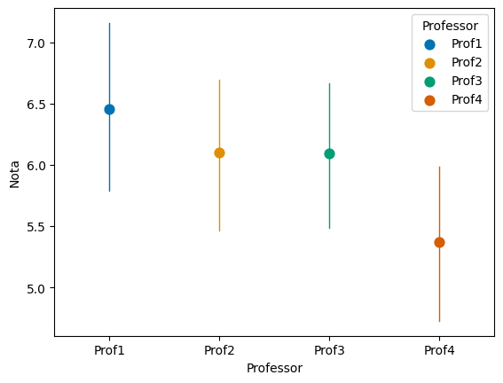

```python
sns.pointplot(data=df, x='Professor', y='Nota', hue='Professor',  errwidth=1, palette='colorblind')

df.groupby('Professor').agg('mean','std')
```

# Teste de normalidade dos dados usando o pacote pingouin

A função *shapiro* testa a hipótese nula $H_0$ de que a amostra é proveniente de uma distribuição normal.

$$\begin{cases} H_0 = \text{Dados vem de uma normal}\\H_1 = \text{Dados não vem de uma normal}\end{cases} $$

```python
# pip install pingouin
import pingouin as pg
```

```python
nivel_significancia = 0.05
pg.normality(data=df, dv='Nota', group='Professor', alpha = nivel_significancia)
```

| Professor | W | pval | normal |
| --- | --- | --- | --- |
| Prof1 | 0.931535 | 0.053943 | True |
| Prof2 | 0.937347 | 0.077172 | True |
| Prof3 | 0.935625 | 0.069383 | True |
| Prof4 | 0.962681 | 0.362035 | True |

# Teste de esfericidade dos dados usando o pacote pingouin

“Esfericidade é a condição em que as variâncias das diferenças entre todas as combinações de grupos (níveis) relacionados são iguais. A violação da esfericidade ocorre quando as variações das diferenças entre todas as combinações de grupos relacionados não são iguais.”

$$\begin{cases} H_0 = \text{Existe esfericidade}\\H_1 = \text{Não existe esfericidade}\end{cases} $$

```python
# https://pingouin-stats.org/build/html/generated/pingouin.sphericity.html

import pingouin as pg
spher, _, chisq, dof, pval =  pg.sphericity(data=df, dv='Nota', subject='Aluno', within=['Professor'],
                                            alpha = nivel_significancia)

# Exibir os resultados de forma mais informativa
print(f"Teste de Mauchly para Esfericidade:")
print(f"Esfericidade Atingida: {spher}")
print(f"Estatística Qui-Quadrado: {round(chisq, 3)}")
print(f"Graus de Liberdade: {dof}")
print(f"Valor-p: {round(pval, 3)}")

# Decidir sobre a esfericidade com base no valor-p
if pval < 0.05:
    print("Rejeitar H0: Esfericidade Não Atingida")
else:
    print("Aceitar H0: Esfericidade Atingida")
```

```
Teste de Mauchly para Esfericidade:
Esfericidade Atingida: False
Estatística Qui-Quadrado: 28.346
Graus de Liberdade: 5
Valor-p: 0.0
Rejeitar H0: Esfericidade Não Atingida
```

## O que fazer se a esfericidade for violada

Em cenários onde o valor p é inferior a 0,05 e rejeitamos a hipótese nula do teste de esfericidade de Mauchly, normalmente aplicamos uma correção aos graus de liberdade usados para calcular o índice F.

Existem três correções que podemos aplicar:

- Huynh-Feldt (menos conservador)
- Greenhouse-Geisser
- Lower-bound (mais conservador)

Cada uma dessas correções tende a aumentar os valores de p na tabela de resultados da ANOVA de medidas repetidas para explicar o fato de que a suposição de esfericidade é violada.

# Ajuste da Anova

$$\begin{cases} H_0: \mu_1 = \mu_2 = \mu_3 = \mu_4\text{ (todas as médias são iguais)}\\H_1: \text{Pelo menos uma é diferente das demais} \end{cases} $$

$$\begin{cases} H_0 = \text{A diferença da média dos 4 grupos} = 0 \\H_1 = \text{A diferença da média dos 4 grupos} \neq 0 \end{cases} $$

```python
# https://pingouin-stats.org/build/html/generated/pingouin.rm_anova.html#pingouin.rm_anova

# Compute the two-way mixed-design ANOVA
aov = pg.rm_anova(dv='Nota', within='Professor', subject='Aluno', data=df, detailed = False)

# Pretty printing of ANOVA summary

pg.print_table(aov)

# 'Source': Nome do fator dentro do grupo
# 'ddof1': Graus de liberdade (numerador)
# 'ddof2': Graus de liberdade (denominador)
# 'F': Valor F
# 'p-unc': Valor p não corrigido
# 'ng2': Tamanho do efeito eta-quadrado generalizado
# 'eps': Fator épsilon de Greenhouse-Geisser (= índice de esfericidade)
# 'p-GG-corr': Valor p corrigido por Greenhouse-Geisser
# 'W-spher': Estatística de teste de esfericidade
# 'p-spher': valor p do teste de esfericidade
# 'sphericity': esfericidade dos dados (booleano)
```

```
=============
ANOVA SUMMARY
=============

Source       ddof1    ddof2       F    p-unc    p-GG-corr    ng2    eps  sphericity      W-spher    p-spher
---------  -------  -------  ------  -------  -----------  -----  -----  ------------  ---------  ---------
Professor        3       87  22.337    0.000        0.000  0.047  0.615  False             0.360      0.000
```

```python
from statsmodels.stats.anova import AnovaRM

anova_md = AnovaRM(data=df, depvar='Nota', subject='Aluno', within=['Professor']).fit()
print(anova_md.summary())
```

```
                 Anova
=======================================
          F Value Num DF  Den DF Pr > F
---------------------------------------
Professor 22.3374 3.0000 87.0000 0.0000
=======================================
```

# Comparações multiplas Post Hoc

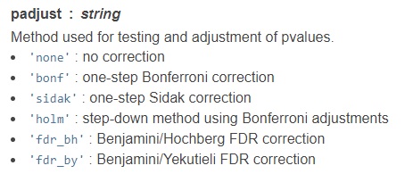

### Bonferroni Conservador

```python
#https://pingouin-stats.org/build/html/generated/pingouin.pairwise_tests.html
posthocs = pg.pairwise_tests(dv='Nota', within='Professor', subject='Aluno', data=df ,
                             padjust = 'bonf', alpha = nivel_significancia)

pg.print_table(posthocs, floatfmt='.2f', tablefmt= 'simple')
# print(posthocs)
```

```
==============
POST HOC TESTS
==============

Contrast    A      B      Paired    Parametric       T    dof  alternative      p-unc    p-corr  p-adjust       BF10    hedges
----------  -----  -----  --------  ------------  ----  -----  -------------  -------  --------  ----------  -------  --------
Professor   Prof1  Prof2  True      True          4.15  29.00  two-sided         0.00      0.00  bonf         106.98      0.19
Professor   Prof1  Prof3  True      True          3.21  29.00  two-sided         0.00      0.02  bonf          11.84      0.20
Professor   Prof1  Prof4  True      True          5.81  29.00  two-sided         0.00      0.00  bonf        7120.86      0.57
Professor   Prof2  Prof3  True      True          0.12  29.00  two-sided         0.91      1.00  bonf           0.20      0.01
Professor   Prof2  Prof4  True      True          4.73  29.00  two-sided         0.00      0.00  bonf         450.44      0.40
Professor   Prof3  Prof4  True      True          4.54  29.00  two-sided         0.00      0.00  bonf         280.93      0.40
```

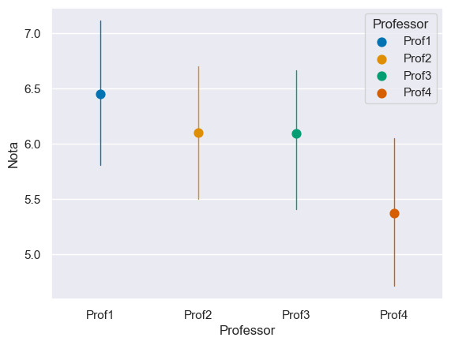

```python
sns.set()
sns.pointplot(data=df, x='Professor', y='Nota', hue='Professor',  errwidth=1, palette='colorblind')
```